# Pattern Recognition With Tracker Data

Der-Hsuan Tsou

5/20/2021

This is a Google Analytics Certificate Project. Data used in this project was retrieved from [Kaggle](https://www.kaggle.com/arashnic/fitbit).There are two main goals for this analysis: **1.** Find the trend in the data **2.**The usage of the trend.

## Environment Set up

```r
# Set the D drive as working directory
setwd("D:/GoogleDataAnalytics/CaseStudy_BellaBeat/FitabaseData")
```

```r
#install.packages("tidyverse")
#install.packages('reshape2')
library(readr)
library(dplyr)
library(lubridate)
```

```r
library(reshape2) #organize correlation heat map matrix
library(ggplot2)
```

## Import Data

```r
DailyAct <- read_csv('dailyActivity_merged.csv')      # Use
# DailyCalo <- read_csv('dailyCalories_merged.csv')     # No
# DailyInten <- read_csv('dailyIntensities_merged.csv') # No
# DailyStep <- read_csv('dailySteps_merged.csv')        # No

#HeartRateS <- read_csv('heartrate_seconds_merged.csv')# Keep
HourCalo <- read_csv('hourlyCalories_merged.csv')     # No
#HourInten <- read_csv('hourlyIntensities_merged.csv') # Keep
HourStep <- read_csv('hourlySteps_merged.csv')        # No
#MinMet <- read_csv('minuteMETsNarrow_merged.csv')     # Keep
#MinSleep <- read_csv('minuteSleep_merged.csv')        # Keep
SleepDay <- read_csv('sleepDay_merged.csv')           # Use
WeightLog<- read_csv('weightLogInfo_merged.csv')      # Use
summary(DailyAct)
```

```
##        Id            ActivityDate         TotalSteps    TotalDistance
##  Min.   :1.504e+09   Length:940         Min.   :    0   Min.   : 0.000
##  1st Qu.:2.320e+09   Class :character   1st Qu.: 3790   1st Qu.: 2.620
##  Median :4.445e+09   Mode  :character   Median : 7406   Median : 5.245
##  Mean   :4.855e+09                      Mean   : 7638   Mean   : 5.490
##  3rd Qu.:6.962e+09                      3rd Qu.:10727   3rd Qu.: 7.713
##  Max.   :8.878e+09                      Max.   :36019   Max.   :28.030
##  TrackerDistance  LoggedActivitiesDistance VeryActiveDistance
##  Min.   : 0.000   Min.   :0.0000           Min.   : 0.000
##  1st Qu.: 2.620   1st Qu.:0.0000           1st Qu.: 0.000
##  Median : 5.245   Median :0.0000           Median : 0.210
##  Mean   : 5.475   Mean   :0.1082           Mean   : 1.503
##  3rd Qu.: 7.710   3rd Qu.:0.0000           3rd Qu.: 2.053
##  Max.   :28.030   Max.   :4.9421           Max.   :21.920
##  ModeratelyActiveDistance LightActiveDistance SedentaryActiveDistance
##  Min.   :0.0000           Min.   : 0.000      Min.   :0.000000
##  1st Qu.:0.0000           1st Qu.: 1.945      1st Qu.:0.000000
##  Median :0.2400           Median : 3.365      Median :0.000000
##  Mean   :0.5675           Mean   : 3.341      Mean   :0.001606
##  3rd Qu.:0.8000           3rd Qu.: 4.782      3rd Qu.:0.000000
##  Max.   :6.4800           Max.   :10.710      Max.   :0.110000
##  VeryActiveMinutes FairlyActiveMinutes LightlyActiveMinutes SedentaryMinutes
##  Min.   :  0.00    Min.   :  0.00      Min.   :  0.0        Min.   :   0.0
##  1st Qu.:  0.00    1st Qu.:  0.00      1st Qu.:127.0        1st Qu.: 729.8
##  Median :  4.00    Median :  6.00      Median :199.0        Median :1057.5
##  Mean   : 21.16    Mean   : 13.56      Mean   :192.8        Mean   : 991.2
##  3rd Qu.: 32.00    3rd Qu.: 19.00      3rd Qu.:264.0        3rd Qu.:1229.5
##  Max.   :210.00    Max.   :143.00      Max.   :518.0        Max.   :1440.0
##     Calories
##  Min.   :   0
##  1st Qu.:1828
##  Median :2134
##  Mean   :2304
##  3rd Qu.:2793
##  Max.   :4900
```

*DailyCalo*, *DailyInten* and *DailyStep* are included in *DailyAct*, thus they will not be used in further analysis.

*HourStep*, *HourCalo* will be used for validation with *DailyAct*.

```r
#summary(DailyCalo)
#summary(DailyInten)
#summary(DailyStep)
#summary(HeartRateS)
summary(HourCalo)
```

```
##        Id            ActivityHour          Calories
##  Min.   :1.504e+09   Length:22099       Min.   : 42.00
##  1st Qu.:2.320e+09   Class :character   1st Qu.: 63.00
##  Median :4.445e+09   Mode  :character   Median : 83.00
##  Mean   :4.848e+09                      Mean   : 97.39
##  3rd Qu.:6.962e+09                      3rd Qu.:108.00
##  Max.   :8.878e+09                      Max.   :948.00
```

```r
#summary(HourInten)
#summary(MinMet) # Not sure what METs is
#summary(MinSleep) # Not sure what value and logid mean
summary(SleepDay) # *Analysis*: TotalSleepRecords and TotalMinutesAsleep TotalTimeInBed
```

```
##        Id              SleepDay         TotalSleepRecords TotalMinutesAsleep
##  Min.   :1.504e+09   Length:413         Min.   :1.000     Min.   : 58.0
##  1st Qu.:3.977e+09   Class :character   1st Qu.:1.000     1st Qu.:361.0
##  Median :4.703e+09   Mode  :character   Median :1.000     Median :433.0
##  Mean   :5.001e+09                      Mean   :1.119     Mean   :419.5
##  3rd Qu.:6.962e+09                      3rd Qu.:1.000     3rd Qu.:490.0
##  Max.   :8.792e+09                      Max.   :3.000     Max.   :796.0
##  TotalTimeInBed
##  Min.   : 61.0
##  1st Qu.:403.0
##  Median :463.0
##  Mean   :458.6
##  3rd Qu.:526.0
##  Max.   :961.0
```

```r
summary(WeightLog)
```

```
##        Id                Date              WeightKg       WeightPounds
##  Min.   :1.504e+09   Length:67          Min.   : 52.60   Min.   :116.0
##  1st Qu.:6.962e+09   Class :character   1st Qu.: 61.40   1st Qu.:135.4
##  Median :6.962e+09   Mode  :character   Median : 62.50   Median :137.8
##  Mean   :7.009e+09                      Mean   : 72.04   Mean   :158.8
##  3rd Qu.:8.878e+09                      3rd Qu.: 85.05   3rd Qu.:187.5
##  Max.   :8.878e+09                      Max.   :133.50   Max.   :294.3
##
##       Fat             BMI        IsManualReport      LogId
##  Min.   :22.00   Min.   :21.45   Mode :logical   Min.   :1.460e+12
##  1st Qu.:22.75   1st Qu.:23.96   FALSE:26        1st Qu.:1.461e+12
##  Median :23.50   Median :24.39   TRUE :41        Median :1.462e+12
##  Mean   :23.50   Mean   :25.19                   Mean   :1.462e+12
##  3rd Qu.:24.25   3rd Qu.:25.56                   3rd Qu.:1.462e+12
##  Max.   :25.00   Max.   :47.54                   Max.   :1.463e+12
##  NA's   :65
```

Validate data with *DailyAct*

Sum of Daily Steps in *HourStep* is not exactly identical to *DailyAct* but they did not differentiate too much. Sum of Daily Calories in *HourCalo* is not exactly identical to *DailyAct* but they did not differentiate too much.

```r
str(HourCalo)
```

```
## spec_tbl_df[,3] [22,099 x 3] (S3: spec_tbl_df/tbl_df/tbl/data.frame)
##  $ Id          : num [1:22099] 1.5e+09 1.5e+09 1.5e+09 1.5e+09 1.5e+09 ...
##  $ ActivityHour: chr [1:22099] "4/12/2016 12:00:00 AM" "4/12/2016 1:00:00 AM" "4/12/2016 2:00:00 AM" "4/12/2016 3:00:00 AM" ...
##  $ Calories    : num [1:22099] 81 61 59 47 48 48 48 47 68 141 ...
##  - attr(*, "spec")=
##   .. cols(
##   ..   Id = col_double(),
##   ..   ActivityHour = col_character(),
##   ..   Calories = col_double()
##   .. )
```

```r
HourCalo$ActivityHour <- as.Date(HourCalo$ActivityHour, format = "%m/%d/%Y")

HourCalo %>%
  group_by(Id, ActivityHour) %>%
  summarise(sum(Calories))
```

```
## # A tibble: 934 x 3
## # Groups:   Id [33]
##            Id ActivityHour `sum(Calories)`
##         <dbl> <date>                 <dbl>
##  1 1503960366 2016-04-12              1988
##  2 1503960366 2016-04-13              1798
##  3 1503960366 2016-04-14              1776
##  4 1503960366 2016-04-15              1745
##  5 1503960366 2016-04-16              1866
##  6 1503960366 2016-04-17              1730
##  7 1503960366 2016-04-18              1920
##  8 1503960366 2016-04-19              2034
##  9 1503960366 2016-04-20              1785
## 10 1503960366 2016-04-21              1777
## # ... with 924 more rows
```

```r
str(HourStep)
```

```
## spec_tbl_df[,3] [22,099 x 3] (S3: spec_tbl_df/tbl_df/tbl/data.frame)
##  $ Id          : num [1:22099] 1.5e+09 1.5e+09 1.5e+09 1.5e+09 1.5e+09 ...
##  $ ActivityHour: chr [1:22099] "4/12/2016 12:00:00 AM" "4/12/2016 1:00:00 AM" "4/12/2016 2:00:00 AM" "4/12/2016 3:00:00 AM" ...
##  $ StepTotal   : num [1:22099] 373 160 151 0 0 ...
##  - attr(*, "spec")=
##   .. cols(
##   ..   Id = col_double(),
##   ..   ActivityHour = col_character(),
##   ..   StepTotal = col_double()
##   .. )
```

```r
HourStep$ActivityHour <- as.Date(HourStep$ActivityHour, format =  "%m/%d/%Y")

HourStep %>%
  group_by(Id, ActivityHour) %>%
  summarise(sum(StepTotal))
```

```
## # A tibble: 934 x 3
## # Groups:   Id [33]
##            Id ActivityHour `sum(StepTotal)`
##         <dbl> <date>                  <dbl>
##  1 1503960366 2016-04-12              13158
##  2 1503960366 2016-04-13              10735
##  3 1503960366 2016-04-14              10460
##  4 1503960366 2016-04-15               9685
##  5 1503960366 2016-04-16              12669
##  6 1503960366 2016-04-17               9705
##  7 1503960366 2016-04-18              13019
##  8 1503960366 2016-04-19              15506
##  9 1503960366 2016-04-20              10544
## 10 1503960366 2016-04-21               9819
## # ... with 924 more rows
```

## Data Exploration

- change data type
- imputation
- plot to find pattern

##### DailyAct

*TotalDistance* and *TrackerDistance* are basically identical.

```r
str(DailyAct)
```

```
## spec_tbl_df[,15] [940 x 15] (S3: spec_tbl_df/tbl_df/tbl/data.frame)
##  $ Id                      : num [1:940] 1.5e+09 1.5e+09 1.5e+09 1.5e+09 1.5e+09 ...
##  $ ActivityDate            : chr [1:940] "4/12/2016" "4/13/2016" "4/14/2016" "4/15/2016" ...
##  $ TotalSteps              : num [1:940] 13162 10735 10460 9762 12669 ...
##  $ TotalDistance           : num [1:940] 8.5 6.97 6.74 6.28 8.16 ...
##  $ TrackerDistance         : num [1:940] 8.5 6.97 6.74 6.28 8.16 ...
##  $ LoggedActivitiesDistance: num [1:940] 0 0 0 0 0 0 0 0 0 0 ...
##  $ VeryActiveDistance      : num [1:940] 1.88 1.57 2.44 2.14 2.71 ...
##  $ ModeratelyActiveDistance: num [1:940] 0.55 0.69 0.4 1.26 0.41 ...
##  $ LightActiveDistance     : num [1:940] 6.06 4.71 3.91 2.83 5.04 ...
##  $ SedentaryActiveDistance : num [1:940] 0 0 0 0 0 0 0 0 0 0 ...
##  $ VeryActiveMinutes       : num [1:940] 25 21 30 29 36 38 42 50 28 19 ...
##  $ FairlyActiveMinutes     : num [1:940] 13 19 11 34 10 20 16 31 12 8 ...
##  $ LightlyActiveMinutes    : num [1:940] 328 217 181 209 221 164 233 264 205 211 ...
##  $ SedentaryMinutes        : num [1:940] 728 776 1218 726 773 ...
##  $ Calories                : num [1:940] 1985 1797 1776 1745 1863 ...
##  - attr(*, "spec")=
##   .. cols(
##   ..   Id = col_double(),
##   ..   ActivityDate = col_character(),
##   ..   TotalSteps = col_double(),
##   ..   TotalDistance = col_double(),
##   ..   TrackerDistance = col_double(),
##   ..   LoggedActivitiesDistance = col_double(),
##   ..   VeryActiveDistance = col_double(),
##   ..   ModeratelyActiveDistance = col_double(),
##   ..   LightActiveDistance = col_double(),
##   ..   SedentaryActiveDistance = col_double(),
##   ..   VeryActiveMinutes = col_double(),
##   ..   FairlyActiveMinutes = col_double(),
##   ..   LightlyActiveMinutes = col_double(),
##   ..   SedentaryMinutes = col_double(),
##   ..   Calories = col_double()
##   .. )
```

```r
DailyAct$Id <- as.factor(DailyAct$Id)
DailyAct$ActivityDate <- as.Date(DailyAct$ActivityDate, format = "%m/%d/%Y")
str(DailyAct)
```

```
## spec_tbl_df[,15] [940 x 15] (S3: spec_tbl_df/tbl_df/tbl/data.frame)
##  $ Id                      : Factor w/ 33 levels "1503960366","1624580081",..: 1 1 1 1 1 1 1 1 1 1 ...
##  $ ActivityDate            : Date[1:940], format: "2016-04-12" "2016-04-13" ...
##  $ TotalSteps              : num [1:940] 13162 10735 10460 9762 12669 ...
##  $ TotalDistance           : num [1:940] 8.5 6.97 6.74 6.28 8.16 ...
##  $ TrackerDistance         : num [1:940] 8.5 6.97 6.74 6.28 8.16 ...
##  $ LoggedActivitiesDistance: num [1:940] 0 0 0 0 0 0 0 0 0 0 ...
##  $ VeryActiveDistance      : num [1:940] 1.88 1.57 2.44 2.14 2.71 ...
##  $ ModeratelyActiveDistance: num [1:940] 0.55 0.69 0.4 1.26 0.41 ...
##  $ LightActiveDistance     : num [1:940] 6.06 4.71 3.91 2.83 5.04 ...
##  $ SedentaryActiveDistance : num [1:940] 0 0 0 0 0 0 0 0 0 0 ...
##  $ VeryActiveMinutes       : num [1:940] 25 21 30 29 36 38 42 50 28 19 ...
##  $ FairlyActiveMinutes     : num [1:940] 13 19 11 34 10 20 16 31 12 8 ...
##  $ LightlyActiveMinutes    : num [1:940] 328 217 181 209 221 164 233 264 205 211 ...
##  $ SedentaryMinutes        : num [1:940] 728 776 1218 726 773 ...
##  $ Calories                : num [1:940] 1985 1797 1776 1745 1863 ...
##  - attr(*, "spec")=
##   .. cols(
##   ..   Id = col_double(),
##   ..   ActivityDate = col_character(),
##   ..   TotalSteps = col_double(),
##   ..   TotalDistance = col_double(),
##   ..   TrackerDistance = col_double(),
##   ..   LoggedActivitiesDistance = col_double(),
##   ..   VeryActiveDistance = col_double(),
##   ..   ModeratelyActiveDistance = col_double(),
##   ..   LightActiveDistance = col_double(),
##   ..   SedentaryActiveDistance = col_double(),
##   ..   VeryActiveMinutes = col_double(),
##   ..   FairlyActiveMinutes = col_double(),
##   ..   LightlyActiveMinutes = col_double(),
##   ..   SedentaryMinutes = col_double(),
##   ..   Calories = col_double()
##   .. )
```

```r
head(DailyAct)
```

```
## # A tibble: 6 x 15
##   Id     ActivityDate TotalSteps TotalDistance TrackerDistance LoggedActivities~
##   <fct>  <date>            <dbl>         <dbl>           <dbl>             <dbl>
## 1 15039~ 2016-04-12        13162          8.5             8.5                  0
## 2 15039~ 2016-04-13        10735          6.97            6.97                 0
## 3 15039~ 2016-04-14        10460          6.74            6.74                 0
## 4 15039~ 2016-04-15         9762          6.28            6.28                 0
## 5 15039~ 2016-04-16        12669          8.16            8.16                 0
## 6 15039~ 2016-04-17         9705          6.48            6.48                 0
## # ... with 9 more variables: VeryActiveDistance <dbl>,
## #   ModeratelyActiveDistance <dbl>, LightActiveDistance <dbl>,
## #   SedentaryActiveDistance <dbl>, VeryActiveMinutes <dbl>,
## #   FairlyActiveMinutes <dbl>, LightlyActiveMinutes <dbl>,
## #   SedentaryMinutes <dbl>, Calories <dbl>
```

```r
summary(DailyAct)
```

```
##           Id       ActivityDate          TotalSteps    TotalDistance
##  1503960366: 31   Min.   :2016-04-12   Min.   :    0   Min.   : 0.000
##  1624580081: 31   1st Qu.:2016-04-19   1st Qu.: 3790   1st Qu.: 2.620
##  1844505072: 31   Median :2016-04-26   Median : 7406   Median : 5.245
##  1927972279: 31   Mean   :2016-04-26   Mean   : 7638   Mean   : 5.490
##  2022484408: 31   3rd Qu.:2016-05-04   3rd Qu.:10727   3rd Qu.: 7.713
##  2026352035: 31   Max.   :2016-05-12   Max.   :36019   Max.   :28.030
##  (Other)   :754
##  TrackerDistance  LoggedActivitiesDistance VeryActiveDistance
##  Min.   : 0.000   Min.   :0.0000           Min.   : 0.000
##  1st Qu.: 2.620   1st Qu.:0.0000           1st Qu.: 0.000
##  Median : 5.245   Median :0.0000           Median : 0.210
##  Mean   : 5.475   Mean   :0.1082           Mean   : 1.503
##  3rd Qu.: 7.710   3rd Qu.:0.0000           3rd Qu.: 2.053
##  Max.   :28.030   Max.   :4.9421           Max.   :21.920
##
##  ModeratelyActiveDistance LightActiveDistance SedentaryActiveDistance
##  Min.   :0.0000           Min.   : 0.000      Min.   :0.000000
##  1st Qu.:0.0000           1st Qu.: 1.945      1st Qu.:0.000000
##  Median :0.2400           Median : 3.365      Median :0.000000
##  Mean   :0.5675           Mean   : 3.341      Mean   :0.001606
##  3rd Qu.:0.8000           3rd Qu.: 4.782      3rd Qu.:0.000000
##  Max.   :6.4800           Max.   :10.710      Max.   :0.110000
##
##  VeryActiveMinutes FairlyActiveMinutes LightlyActiveMinutes SedentaryMinutes
##  Min.   :  0.00    Min.   :  0.00      Min.   :  0.0        Min.   :   0.0
##  1st Qu.:  0.00    1st Qu.:  0.00      1st Qu.:127.0        1st Qu.: 729.8
##  Median :  4.00    Median :  6.00      Median :199.0        Median :1057.5
##  Mean   : 21.16    Mean   : 13.56      Mean   :192.8        Mean   : 991.2
##  3rd Qu.: 32.00    3rd Qu.: 19.00      3rd Qu.:264.0        3rd Qu.:1229.5
##  Max.   :210.00    Max.   :143.00      Max.   :518.0        Max.   :1440.0
##
##     Calories
##  Min.   :   0
##  1st Qu.:1828
##  Median :2134
##  Mean   :2304
##  3rd Qu.:2793
##  Max.   :4900
##
```

```r
unique(DailyAct$Id) # 33 unique ID
```

```
##  [1] 1503960366 1624580081 1644430081 1844505072 1927972279 2022484408
##  [7] 2026352035 2320127002 2347167796 2873212765 3372868164 3977333714
## [13] 4020332650 4057192912 4319703577 4388161847 4445114986 4558609924
## [19] 4702921684 5553957443 5577150313 6117666160 6290855005 6775888955
## [25] 6962181067 7007744171 7086361926 8053475328 8253242879 8378563200
## [31] 8583815059 8792009665 8877689391
## 33 Levels: 1503960366 1624580081 1644430081 1844505072 ... 8877689391
```

build a *DailyAct* numeric variable correlation map

```
##                          TotalSteps TotalDistance LoggedActivitiesDistance
## TotalSteps                     1.00          0.99                     0.18
## TotalDistance                  0.99          1.00                     0.19
## LoggedActivitiesDistance       0.18          0.19                     1.00
## VeryActiveDistance             0.74          0.79                     0.15
## ModeratelyActiveDistance       0.51          0.47                     0.08
## LightActiveDistance            0.69          0.66                     0.14
##                          VeryActiveDistance ModeratelyActiveDistance
## TotalSteps                             0.74                     0.51
## TotalDistance                          0.79                     0.47
## LoggedActivitiesDistance               0.15                     0.08
## VeryActiveDistance                     1.00                     0.19
## ModeratelyActiveDistance               0.19                     1.00
## LightActiveDistance                    0.16                     0.24
##                          LightActiveDistance SedentaryActiveDistance
## TotalSteps                              0.69                    0.07
## TotalDistance                           0.66                    0.08
## LoggedActivitiesDistance                0.14                    0.15
## VeryActiveDistance                      0.16                    0.05
## ModeratelyActiveDistance                0.24                    0.01
## LightActiveDistance                     1.00                    0.10
##                          VeryActiveMinutes FairlyActiveMinutes
## TotalSteps                            0.67                0.50
## TotalDistance                         0.68                0.46
## LoggedActivitiesDistance              0.23                0.05
## VeryActiveDistance                    0.83                0.21
## ModeratelyActiveDistance              0.23                0.95
## LightActiveDistance                   0.15                0.22
##                          LightlyActiveMinutes SedentaryMinutes Calories
## TotalSteps                               0.57            -0.33     0.59
## TotalDistance                            0.52            -0.29     0.64
## LoggedActivitiesDistance                 0.10            -0.05     0.21
## VeryActiveDistance                       0.06            -0.06     0.49
## ModeratelyActiveDistance                 0.16            -0.22     0.22
## LightActiveDistance                      0.89            -0.41     0.47
```

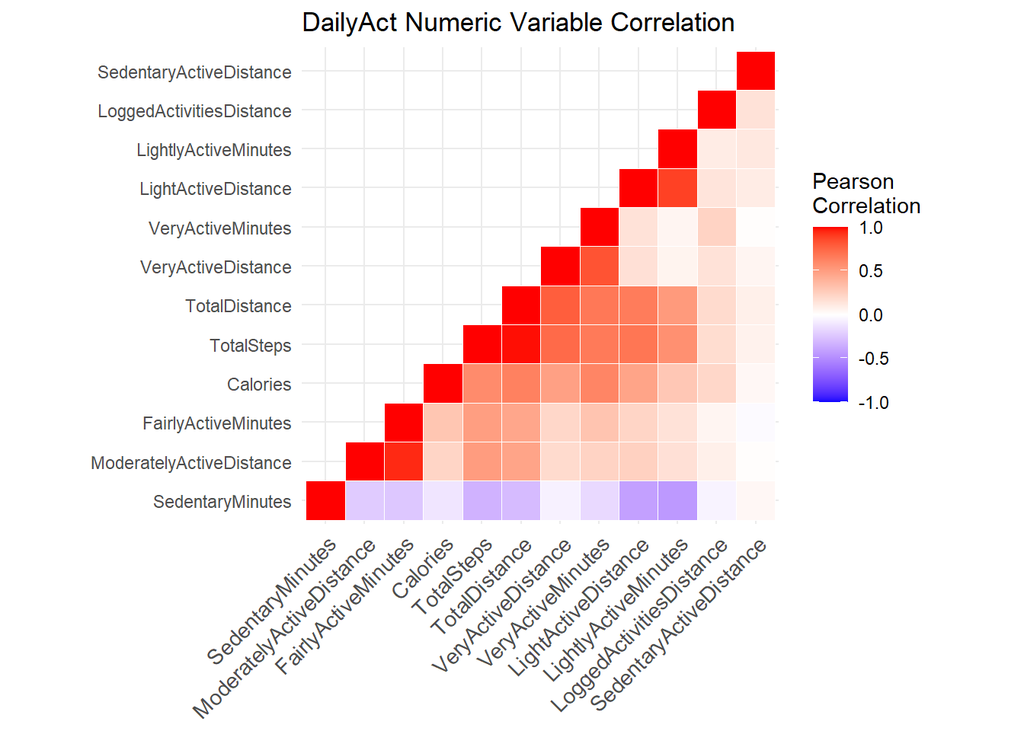

- Negative relationship happened between *SedentaryMinutes*, *LightActiveDistance* (-0.41) and *LightlyActiveMinutes*(-0.44)
- Positive relationship(0.95) happened between*ModeratelyActiveDistance* and *FairlyActiveMinutes*
- slightly positive relationship(0.04) between *SedentaryActiveDistance* and *SedentaryMinutes*, which is normal
- positive relationship(0.89) shared between *LightActiveDistance* and *LightlyActiveMinutes*
- positive relationship(0.83) shared between *VeryActiveDistance* and *VeryActiveMinutes*

##### SleepDay

```r
str(SleepDay)
```

```
## spec_tbl_df[,5] [413 x 5] (S3: spec_tbl_df/tbl_df/tbl/data.frame)
##  $ Id                : num [1:413] 1.5e+09 1.5e+09 1.5e+09 1.5e+09 1.5e+09 ...
##  $ SleepDay          : chr [1:413] "4/12/2016 12:00:00 AM" "4/13/2016 12:00:00 AM" "4/15/2016 12:00:00 AM" "4/16/2016 12:00:00 AM" ...
##  $ TotalSleepRecords : num [1:413] 1 2 1 2 1 1 1 1 1 1 ...
##  $ TotalMinutesAsleep: num [1:413] 327 384 412 340 700 304 360 325 361 430 ...
##  $ TotalTimeInBed    : num [1:413] 346 407 442 367 712 320 377 364 384 449 ...
##  - attr(*, "spec")=
##   .. cols(
##   ..   Id = col_double(),
##   ..   SleepDay = col_character(),
##   ..   TotalSleepRecords = col_double(),
##   ..   TotalMinutesAsleep = col_double(),
##   ..   TotalTimeInBed = col_double()
##   .. )
```

```r
SleepDay <- SleepDay %>%
  rename(SleepDatetime = SleepDay)
SleepDay$Id <- as.factor(SleepDay$Id)
# separate the date the time as the time are all the same, omit SleepDatetime column
SleepDay$SleepDate <- substr(SleepDay$SleepDatetime, 1, 9)
SleepDay$SleepDate <- as.Date(SleepDay$SleepDate, format = "%m/%d/%Y") #time only starts from 12AM
SleepDay$Weekday <- wday(SleepDay$SleepDate, label = TRUE, week_start = 1)
str(SleepDay)
```

```
## spec_tbl_df[,7] [413 x 7] (S3: spec_tbl_df/tbl_df/tbl/data.frame)
##  $ Id                : Factor w/ 24 levels "1503960366","1644430081",..: 1 1 1 1 1 1 1 1 1 1 ...
##  $ SleepDatetime     : chr [1:413] "4/12/2016 12:00:00 AM" "4/13/2016 12:00:00 AM" "4/15/2016 12:00:00 AM" "4/16/2016 12:00:00 AM" ...
##  $ TotalSleepRecords : num [1:413] 1 2 1 2 1 1 1 1 1 1 ...
##  $ TotalMinutesAsleep: num [1:413] 327 384 412 340 700 304 360 325 361 430 ...
##  $ TotalTimeInBed    : num [1:413] 346 407 442 367 712 320 377 364 384 449 ...
##  $ SleepDate         : Date[1:413], format: "2016-04-12" "2016-04-13" ...
##  $ Weekday           : Ord.factor w/ 7 levels "Mon"<"Tue"<"Wed"<..: 2 3 5 6 7 2 3 4 6 7 ...
##  - attr(*, "spec")=
##   .. cols(
##   ..   Id = col_double(),
##   ..   SleepDay = col_character(),
##   ..   TotalSleepRecords = col_double(),
##   ..   TotalMinutesAsleep = col_double(),
##   ..   TotalTimeInBed = col_double()
##   .. )
```

```r
head(SleepDay)
```

```
## # A tibble: 6 x 7
##   Id        SleepDatetime      TotalSleepRecor~ TotalMinutesAsle~ TotalTimeInBed
##   <fct>     <chr>                         <dbl>             <dbl>          <dbl>
## 1 15039603~ 4/12/2016 12:00:0~                1               327            346
## 2 15039603~ 4/13/2016 12:00:0~                2               384            407
## 3 15039603~ 4/15/2016 12:00:0~                1               412            442
## 4 15039603~ 4/16/2016 12:00:0~                2               340            367
## 5 15039603~ 4/17/2016 12:00:0~                1               700            712
## 6 15039603~ 4/19/2016 12:00:0~                1               304            320
## # ... with 2 more variables: SleepDate <date>, Weekday <ord>
```

```r
summary(SleepDay)
```

```
##           Id      SleepDatetime      TotalSleepRecords TotalMinutesAsleep
##  8378563200: 32   Length:413         Min.   :1.000     Min.   : 58.0
##  5553957443: 31   Class :character   1st Qu.:1.000     1st Qu.:361.0
##  6962181067: 31   Mode  :character   Median :1.000     Median :433.0
##  2026352035: 28                      Mean   :1.119     Mean   :419.5
##  3977333714: 28                      3rd Qu.:1.000     3rd Qu.:490.0
##  4445114986: 28                      Max.   :3.000     Max.   :796.0
##  (Other)   :235
##  TotalTimeInBed    SleepDate          Weekday
##  Min.   : 61.0   Min.   :2016-04-12   Mon:47
##  1st Qu.:403.0   1st Qu.:2016-04-19   Tue:65
##  Median :463.0   Median :2016-04-27   Wed:66
##  Mean   :458.6   Mean   :2016-04-26   Thu:65
##  3rd Qu.:526.0   3rd Qu.:2016-05-04   Fri:57
##  Max.   :961.0   Max.   :2016-05-12   Sat:58
##                                       Sun:55
```

```r
unique(SleepDay$Id) # 24 unique Id
```

```
##  [1] 1503960366 1644430081 1844505072 1927972279 2026352035 2320127002
##  [7] 2347167796 3977333714 4020332650 4319703577 4388161847 4445114986
## [13] 4558609924 4702921684 5553957443 5577150313 6117666160 6775888955
## [19] 6962181067 7007744171 7086361926 8053475328 8378563200 8792009665
## 24 Levels: 1503960366 1644430081 1844505072 1927972279 ... 8792009665
```

Use bar chart to find the trend for *TotalMinutesAsleep*, *TotalTimeInBed* and *SleepDate*

```r
Slplt_Date <- SleepDay %>%
  select(TotalMinutesAsleep, TotalTimeInBed, SleepDate) %>%
  group_by(SleepDate) %>%
  summarise(TotalMinutesAsleep = mean(TotalMinutesAsleep), TotalTimeInBed = mean(TotalTimeInBed))
Slplt_Date02 <- melt(Slplt_Date, id.vars = 'SleepDate')
```

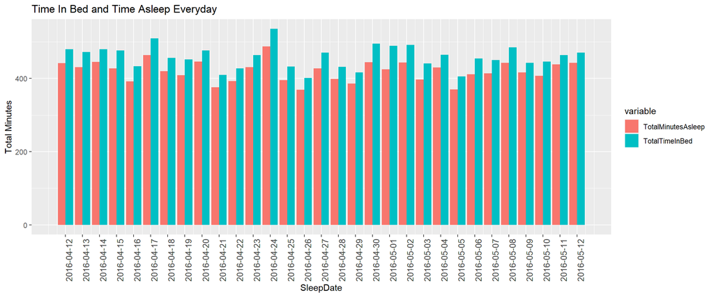

```r
plt <- ggplot(Slplt_Date02, aes(x = SleepDate, y = value, fill = variable)) +
  geom_bar(stat = 'identity', position = 'dodge') +
  scale_x_date(breaks = Slplt_Date02$SleepDate) +
  theme(axis.text.x = element_text(angle = 90, size = 10)) +
  labs(y = 'Total Minutes', title = 'Time In Bed and Time Asleep Everyday')
plt
```

Limited info is found in this bar chart, thus below are zoomed in line chart between *TotalMinutesAsleep*, *TotalTimeInBed* and *SleepDate*. The line chart below can tell better difference between *TotalMinutesAsleep*, *TotalTimeInBed* and *SleepDate*.

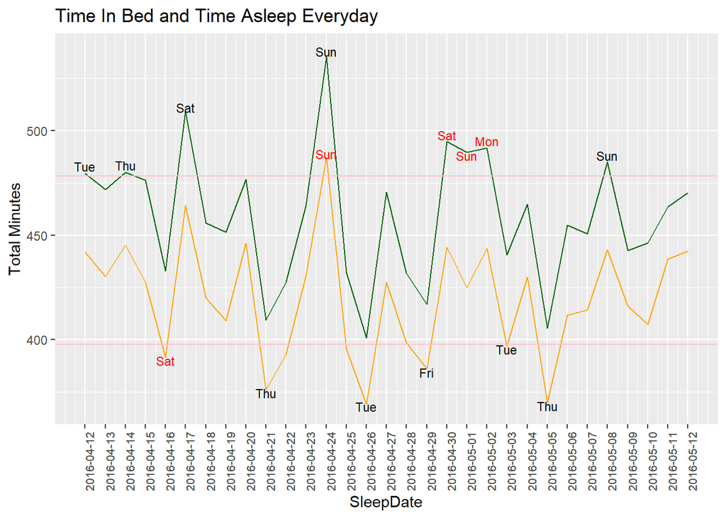

```r
plt <- ggplot(data = Slplt_Date, aes(x = SleepDate)) +
  geom_line(aes(y = TotalMinutesAsleep), color = 'orange') +
  geom_line(aes(y = TotalTimeInBed), color = 'dark green') +
  labs(y = 'Total Minutes', title = "Time In Bed and Time Asleep Everyday") +
  scale_x_date(breaks = Slplt_Date02$SleepDate) +
  theme(axis.text.x = element_text(angle = 90, size = 8)) +
  geom_hline(yintercept = 397.8, color = 'pink') +
  geom_hline(yintercept = 478.2, color = 'pink') +
  annotate("text", x= as.Date('2016-04-16'), y=390, label = "Sat",
           color ='red', size=3) +
  annotate("text", x= as.Date('2016-04-21'), y=374.5, label = "Thu",
           color ='black', size=3) +
  annotate("text", x= as.Date('2016-04-26'), y=368, label = "Tue",
           color ='black', size=3) +
  annotate("text", x= as.Date('2016-04-29'), y=384.5, label = "Fri",
           color ='black', size=3) +
  annotate("text", x= as.Date('2016-05-03'), y=395.5, label = "Tue",
           color ='black', size=3) +
  annotate("text", x= as.Date('2016-05-05'), y=368.5, label = "Thu",
           color ='black', size=3) +
  annotate("text", x= as.Date('2016-04-12'), y=483, label = "Tue",
           color ='black', size=3) +
  annotate("text", x= as.Date('2016-04-14'), y=483.5, label = "Thu",
           color ='black', size=3) +
  annotate("text", x= as.Date('2016-04-17'), y=511, label = "Sat",
           color ='black', size=3) +
  annotate("text", x= as.Date('2016-04-24'), y=538, label = "Sun",
           color ='black', size=3) +
  annotate("text", x= as.Date('2016-04-24'), y=489, label = "Sun",
           color ='red', size=3) +
  annotate("text", x= as.Date('2016-04-30'), y=498, label = "Sat",
           color ='red', size=3) +
  annotate("text", x= as.Date('2016-05-01'), y=488, label = "Sun",
           color ='red', size=3) +
  annotate("text", x= as.Date('2016-05-02'), y=495, label = "Mon",
           color ='red', size=3) +
  annotate("text", x= as.Date('2016-05-08'), y=488, label = "Sun",
           color ='black', size=3)
plt
```

The chart for days in the week were plotted below for deeper analysis.

```r
Slplt_Weekday <- SleepDay %>%
  select(TotalMinutesAsleep, TotalTimeInBed, Weekday) %>%
  group_by(Weekday) %>%
  summarise(TotalMinutesAsleep = mean(TotalMinutesAsleep), TotalTimeInBed = mean(TotalTimeInBed))
Slplt_Weekday02 <- melt(Slplt_Weekday, id.vars = 'Weekday')
```

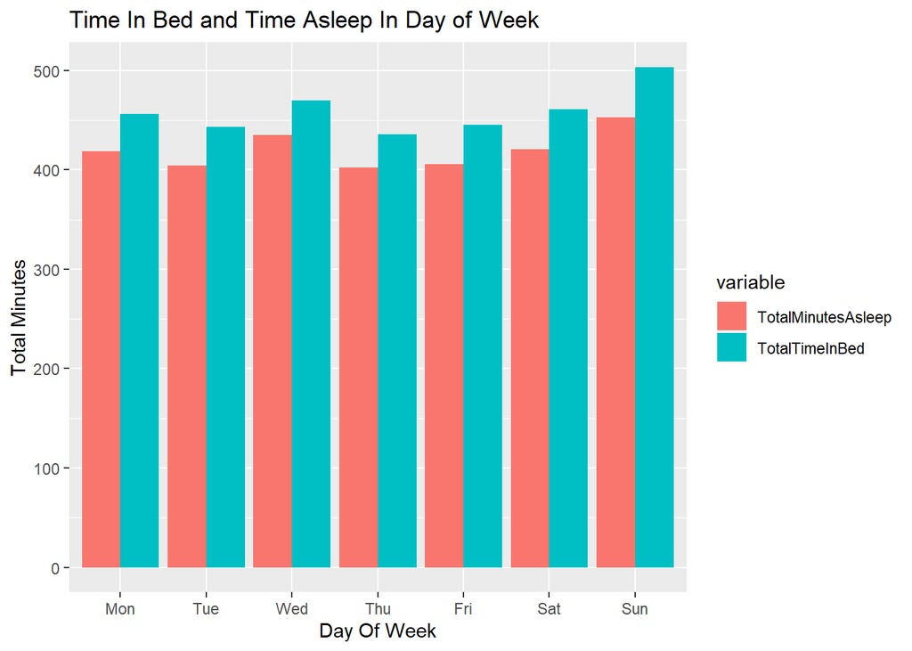

```r
plt <- ggplot(data = Slplt_Weekday02, aes(x = Weekday, y = value, fill = variable)) +
  geom_bar(stat = 'identity', position = 'dodge') +
  labs(x = "Day Of Week", y = 'Total Minutes', title = "Time In Bed and Time Asleep In Day of Week")
plt
```

I thought people will spend more time in bed and sleep more on the weekends, however, our data show a different story. They tend to sleep the most on Sunday and Wednesday. This raises my curiosity in what kind of occupation the 24 people are.

##### WeightLog

```r
str(WeightLog)
```

```
## spec_tbl_df[,8] [67 x 8] (S3: spec_tbl_df/tbl_df/tbl/data.frame)
##  $ Id            : num [1:67] 1.50e+09 1.50e+09 1.93e+09 2.87e+09 2.87e+09 ...
##  $ Date          : chr [1:67] "5/2/2016 11:59:59 PM" "5/3/2016 11:59:59 PM" "4/13/2016 1:08:52 AM" "4/21/2016 11:59:59 PM" ...
##  $ WeightKg      : num [1:67] 52.6 52.6 133.5 56.7 57.3 ...
##  $ WeightPounds  : num [1:67] 116 116 294 125 126 ...
##  $ Fat           : num [1:67] 22 NA NA NA NA 25 NA NA NA NA ...
##  $ BMI           : num [1:67] 22.6 22.6 47.5 21.5 21.7 ...
##  $ IsManualReport: logi [1:67] TRUE TRUE FALSE TRUE TRUE TRUE ...
##  $ LogId         : num [1:67] 1.46e+12 1.46e+12 1.46e+12 1.46e+12 1.46e+12 ...
##  - attr(*, "spec")=
##   .. cols(
##   ..   Id = col_double(),
##   ..   Date = col_character(),
##   ..   WeightKg = col_double(),
##   ..   WeightPounds = col_double(),
##   ..   Fat = col_double(),
##   ..   BMI = col_double(),
##   ..   IsManualReport = col_logical(),
##   ..   LogId = col_double()
##   .. )
```

```r
WeightLog$Id <- as.factor(WeightLog$Id)
WeightLog$RecordDate <- substr(WeightLog$Date, 1, 9)
WeightLog$RecordDate <- as.Date(WeightLog$RecordDate, format = '%m/%d/%Y')
WeightLog$Date <- mdy_hms(WeightLog$Date, tz=Sys.timezone())
str(WeightLog)
```

```
## spec_tbl_df[,9] [67 x 9] (S3: spec_tbl_df/tbl_df/tbl/data.frame)
##  $ Id            : Factor w/ 8 levels "1503960366","1927972279",..: 1 1 2 3 3 4 4 5 5 5 ...
##  $ Date          : POSIXct[1:67], format: "2016-05-02 23:59:59" "2016-05-03 23:59:59" ...
##  $ WeightKg      : num [1:67] 52.6 52.6 133.5 56.7 57.3 ...
##  $ WeightPounds  : num [1:67] 116 116 294 125 126 ...
##  $ Fat           : num [1:67] 22 NA NA NA NA 25 NA NA NA NA ...
##  $ BMI           : num [1:67] 22.6 22.6 47.5 21.5 21.7 ...
##  $ IsManualReport: logi [1:67] TRUE TRUE FALSE TRUE TRUE TRUE ...
##  $ LogId         : num [1:67] 1.46e+12 1.46e+12 1.46e+12 1.46e+12 1.46e+12 ...
##  $ RecordDate    : Date[1:67], format: "2016-05-02" "2016-05-03" ...
##  - attr(*, "spec")=
##   .. cols(
##   ..   Id = col_double(),
##   ..   Date = col_character(),
##   ..   WeightKg = col_double(),
##   ..   WeightPounds = col_double(),
##   ..   Fat = col_double(),
##   ..   BMI = col_double(),
##   ..   IsManualReport = col_logical(),
##   ..   LogId = col_double()
##   .. )
```

```r
summary(WeightLog) #65/67 NA in Fat so will not be used for further analysis
```

```
##           Id          Date                        WeightKg       WeightPounds
##  6962181067:30   Min.   :2016-04-12 06:47:11   Min.   : 52.60   Min.   :116.0
##  8877689391:24   1st Qu.:2016-04-19 15:19:45   1st Qu.: 61.40   1st Qu.:135.4
##  4558609924: 5   Median :2016-04-27 23:59:59   Median : 62.50   Median :137.8
##  1503960366: 2   Mean   :2016-04-27 15:39:54   Mean   : 72.04   Mean   :158.8
##  2873212765: 2   3rd Qu.:2016-05-04 15:24:10   3rd Qu.: 85.05   3rd Qu.:187.5
##  4319703577: 2   Max.   :2016-05-12 23:59:59   Max.   :133.50   Max.   :294.3
##  (Other)   : 2
##       Fat             BMI        IsManualReport      LogId
##  Min.   :22.00   Min.   :21.45   Mode :logical   Min.   :1.460e+12
##  1st Qu.:22.75   1st Qu.:23.96   FALSE:26        1st Qu.:1.461e+12
##  Median :23.50   Median :24.39   TRUE :41        Median :1.462e+12
##  Mean   :23.50   Mean   :25.19                   Mean   :1.462e+12
##  3rd Qu.:24.25   3rd Qu.:25.56                   3rd Qu.:1.462e+12
##  Max.   :25.00   Max.   :47.54                   Max.   :1.463e+12
##  NA's   :65
##    RecordDate
##  Min.   :2016-04-12
##  1st Qu.:2016-04-19
##  Median :2016-04-27
##  Mean   :2016-04-26
##  3rd Qu.:2016-05-04
##  Max.   :2016-05-12
##
```

```r
WeightLog <- WeightLog %>%
  select(-Fat)
unique(WeightLog$Id) # 8 unique Id
```

```
## [1] 1503960366 1927972279 2873212765 4319703577 4558609924 5577150313 6962181067
## [8] 8877689391
## 8 Levels: 1503960366 1927972279 2873212765 4319703577 ... 8877689391
```

```r
df <- WeightLog %>%
  select(RecordDate, WeightPounds, BMI) %>%
  group_by(RecordDate) %>%
  summarise(AVGWeight = mean(WeightPounds), AVGBMI = mean(BMI))
```

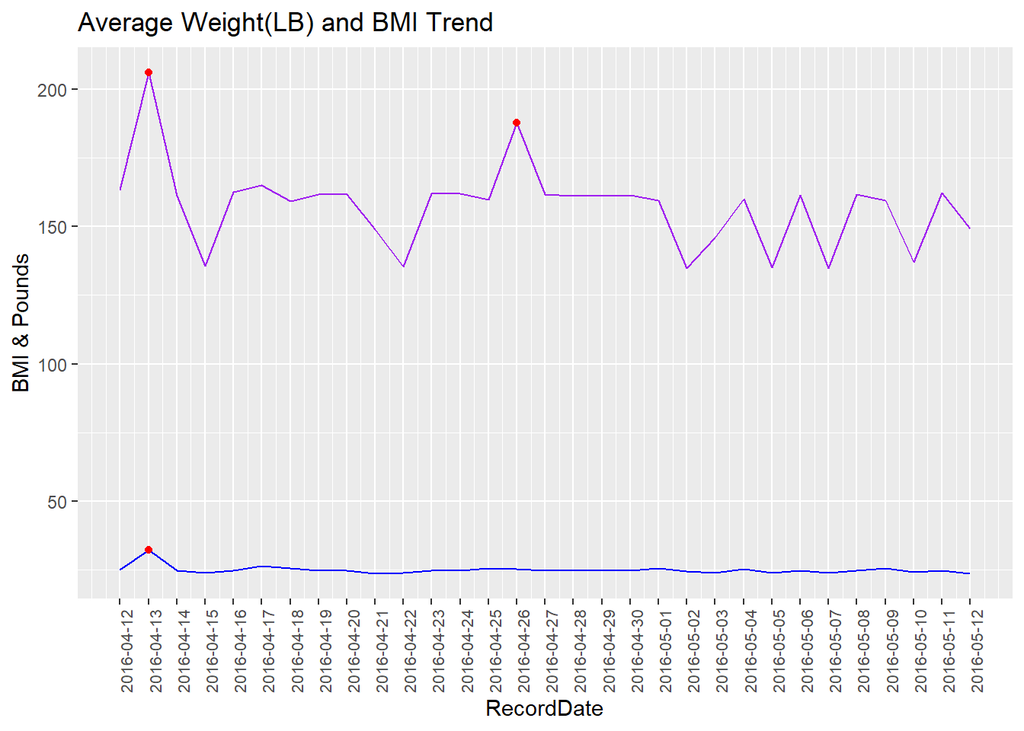

```r
plt <- ggplot(data = df, aes(x= RecordDate)) +
  geom_line(aes(y = AVGWeight), color = 'purple') +
  geom_line(aes(y = AVGBMI), color = 'blue') +
  labs(y = 'BMI & Pounds') +
  scale_x_date(breaks = df$RecordDate) +
  theme(axis.text.x = element_text(angle = 90, size = 8)) +
  geom_point(aes(x = as.Date('2016-04-13'), y = 206.1322), color = 'red') +
  geom_point(aes(x = as.Date('2016-04-13'), y = 32.39667), color = 'red') +
  geom_point(aes(x = as.Date('2016-04-26'), y = 187.6134), color = 'red') +
  labs(title = 'Average Weight(LB) and BMI Trend')
plt
```

Based on the line chart above, there are three data points marked in red on April, 13th and April, 26th, which are abnormal and extremely high. Further analysis will be conducted.

Below, I will drill deeper to see the potential reason for both *WeightPounds* and *BMI* being high on April, 13th and *WeightPounds* High but *BMI* normal on April, 26th.

```r
Weight_df <- WeightLog %>%
  select(Id, RecordDate, WeightPounds, BMI) %>%
  group_by(Id) %>%
  count(Id) %>%
  arrange(Id)
Weight_df
```

```
## # A tibble: 8 x 2
## # Groups:   Id [8]
##   Id             n
##   <fct>      <int>
## 1 1503960366     2
## 2 1927972279     1
## 3 2873212765     2
## 4 4319703577     2
## 5 4558609924     5
## 6 5577150313     1
## 7 6962181067    30
## 8 8877689391    24
```

```r
df <- WeightLog %>%
  select(Id, RecordDate, WeightPounds, BMI) %>%
  filter(RecordDate == '2016-04-13'| RecordDate == '2016-04-26')
df
```

```
## # A tibble: 4 x 4
##   Id         RecordDate WeightPounds   BMI
##   <fct>      <date>            <dbl> <dbl>
## 1 1927972279 2016-04-13         294.  47.5
## 2 6962181067 2016-04-13         137.  24.2
## 3 8877689391 2016-04-13         187.  25.4
## 4 8877689391 2016-04-26         188.  25.5
```

According to two of the zoomed in data, which the first one grouped and counted by the *Id* ; the second one filtered on only the two days we cared about(4/13 & 4/26), I am guessing two facts:

1. *Id* 1927972279 has obesity and *Id* 1927972279 has only one record, which led to both *WeightPounds* and *BMI* raise on April 13th
2. *Id* 8877689391 is tall, which caused only the *WeightPounds* raised. Besides, April 26th has only one record, which is *Id* 8877689391. That explained although *Id* 8877689391 has total 24 records in the *WeightLog* data, only April 26th was affected.
- The above assumptions are based on the information I have, further validation would need more data such as height.

## Reference

FitBit Fitness Tracker Data. Kaggle. https://www.kaggle.com/arashnic/fitbit.

ggplot2 : Quick correlation matrix heatmap - R software and data visualization. STHDA. http://www.sthda.com/english/wiki/ggplot2-quick-correlation-matrix-heatmap-r-software-and-data-visualization